# HW 3 Solutions

Tom Keefe

August 27, 2020

# Instructions

**Exercises:** 1,3 (Pgs. 90-91); 1 (Pg. 93); 2,4 (Pg. 99); 1,2 (Pg. 101); 2,3,5 (Pg. 104)

**Assigned:** Friday, September 14, 2018

**Due:** Friday, September 21, 2018 by 5:00 PM

**Submission:** Submit via an electronic document on Sakai. Must be submitted as a HTML file generated in RStudio. All assigned problems are chosen according to the textbook *R for Data Science*. You do not need R code to answer every question. If you answer without using R code, delete the code chunk. If the question requires R code, make sure you display R code. If the question requires a figure, make sure you display a figure. A lot of the questions can be answered in written response, but require R code and/or figures for understanding and explaining.

# Chapter 5 (Pgs. 90-91)

## Exercise 1

To explore the distributions of x, y, and z, we could either use multiple histograms, or one freq poly chart. Either are acceptable.

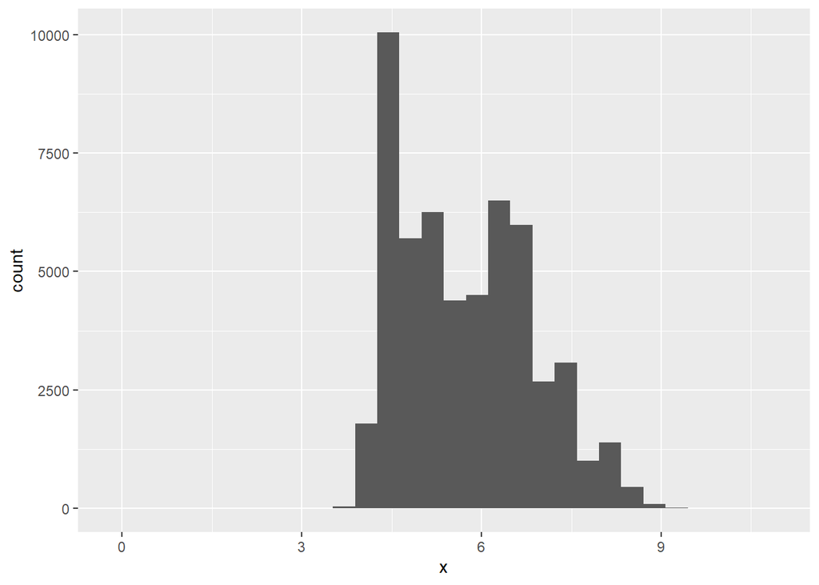

```r
# Distributions of x, y, and z.
ggplot(diamonds, aes(x=x)) + geom_histogram()
```

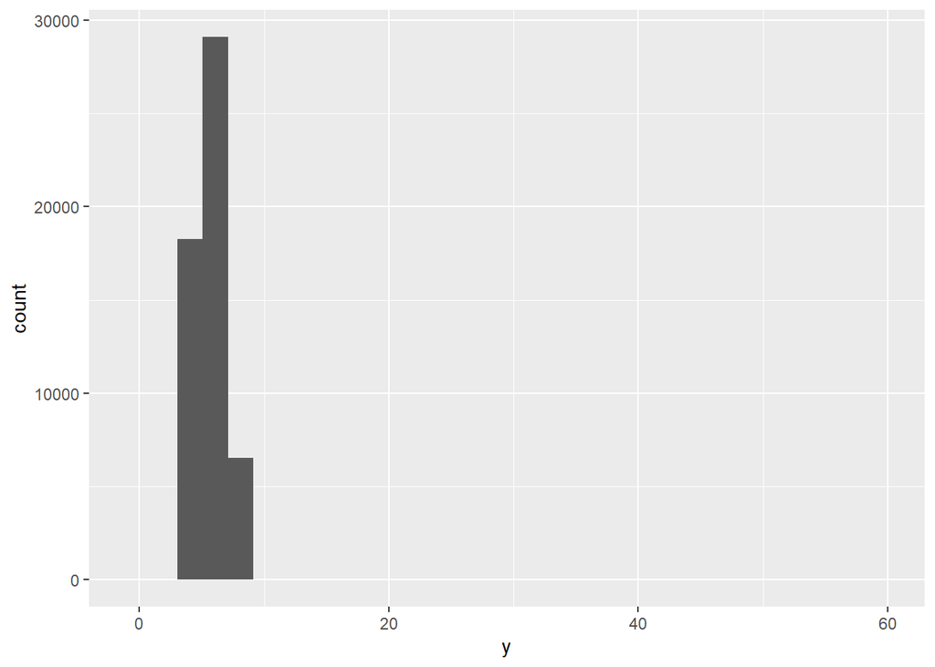

```r
ggplot(diamonds, aes(x=y)) + geom_histogram()
```

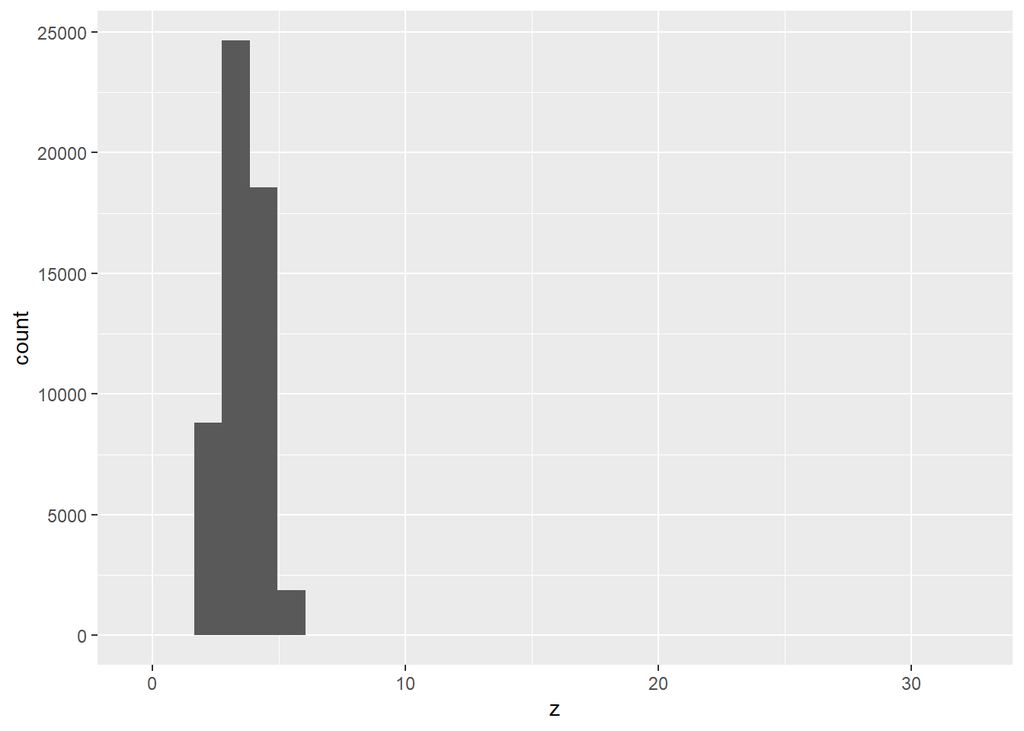

```r
ggplot(diamonds, aes(x=z)) + geom_histogram()
```

Since the histograms don’t appear to fill up the whole horizontal axis, we conclude that there are some far out outliers. However, we we can see that the `x` values mostly range from 3 to 10, the `y` values from about 4 to 10, and the `z` values from 2 to 7. These are rough estimates from the charts. We can use these estimates to zoom in on the histogram and see more detail in the histogram. Additionally, I note from `?diamonds` that these values are measured in millimeters. Since my visual acuity is not much better than 0.5 mm, I choose this as the binwidth.

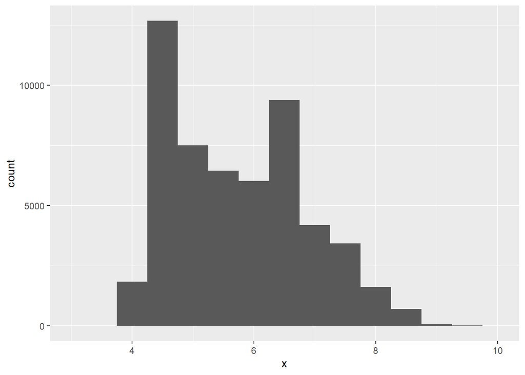

```r
ggplot(diamonds, aes(x=x)) + geom_histogram(binwidth=0.5) + xlim(c(3, 10))
```

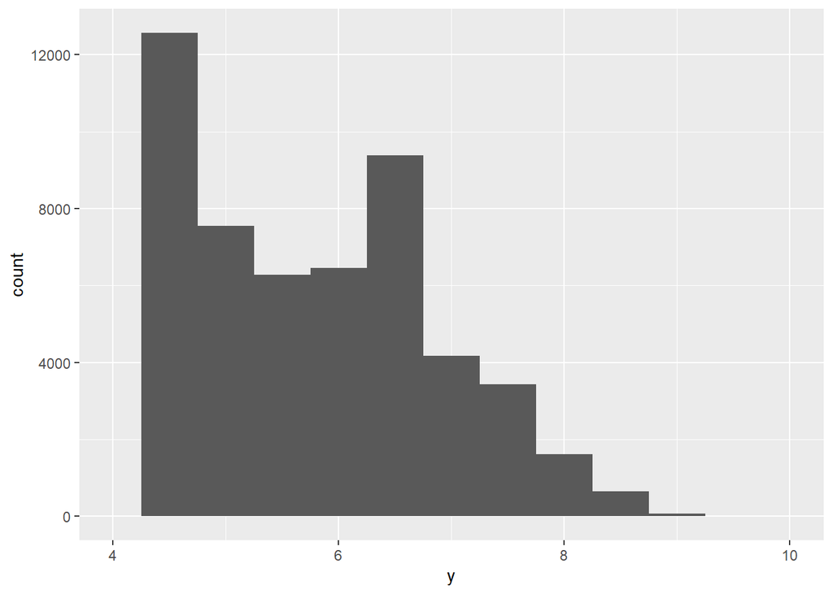

```r
ggplot(diamonds, aes(x=y)) + geom_histogram(binwidth=0.5) + xlim(c(4, 10))
```

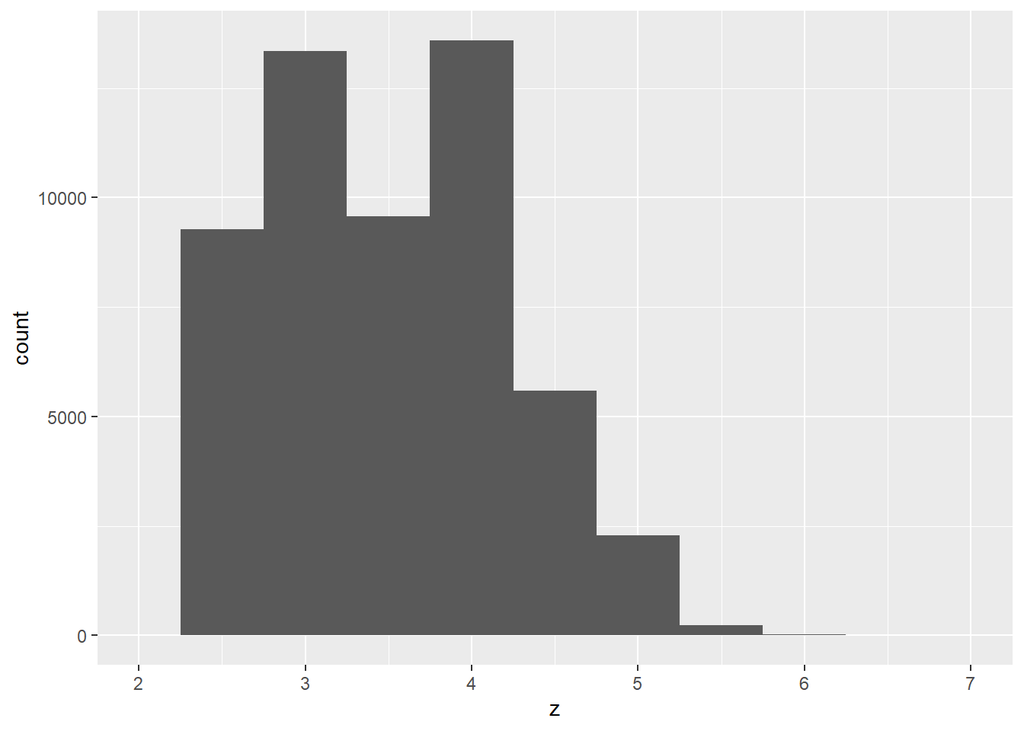

```r
ggplot(diamonds, aes(x=z)) + geom_histogram(binwidth=0.5) + xlim(c(2, 7))
```

We can see that the bulk of the `x` values are between 4 and 9mm, the `y` values also between 4 and 9mm, and the z values between 2 and 6mm. In all cases the distributions are skew right. This makes sense because it is impossible for the values to be negative.

I would suppose that `z` is the thickness of the diamond. It’s not clear to me what length and width mean for diamonds, because they’re usually round. Additionally, `x` and `y` have similar distributions when we remove outliers. However, in `?diamonds` it is revealed that `x` is length, `y` is width, and `z` is depth.

## Exercise 3

```r
# There are multiple ways to get this data.
diamonds %>% filter(carat %in% (c(.99, 1))) %>% count(carat)
```

```
## # A tibble: 2 x 2
##   carat     n
##   <dbl> <int>
## 1  0.99    23
## 2  1     1558
```

23 diamonds are 0.99 carat, 1558 diamonds are 1.00 carat. This is probably a matter of measurement: some people measuring diamonds may round to the nearest whole number or nearest tenth; in both cases this would result in a larger quantity of 1.00 measurements than 0.99 measurements.

# Chapter 5 (Pg. 93)

## Exercise 1

The answer has to do with how missing values are handled in categorical variables. Recall that geom_histogram is meant for visualizing continuous variables, while geom_bar is for categorical variables. We will create some categorical data and continous data that both have NA values to see the difference.

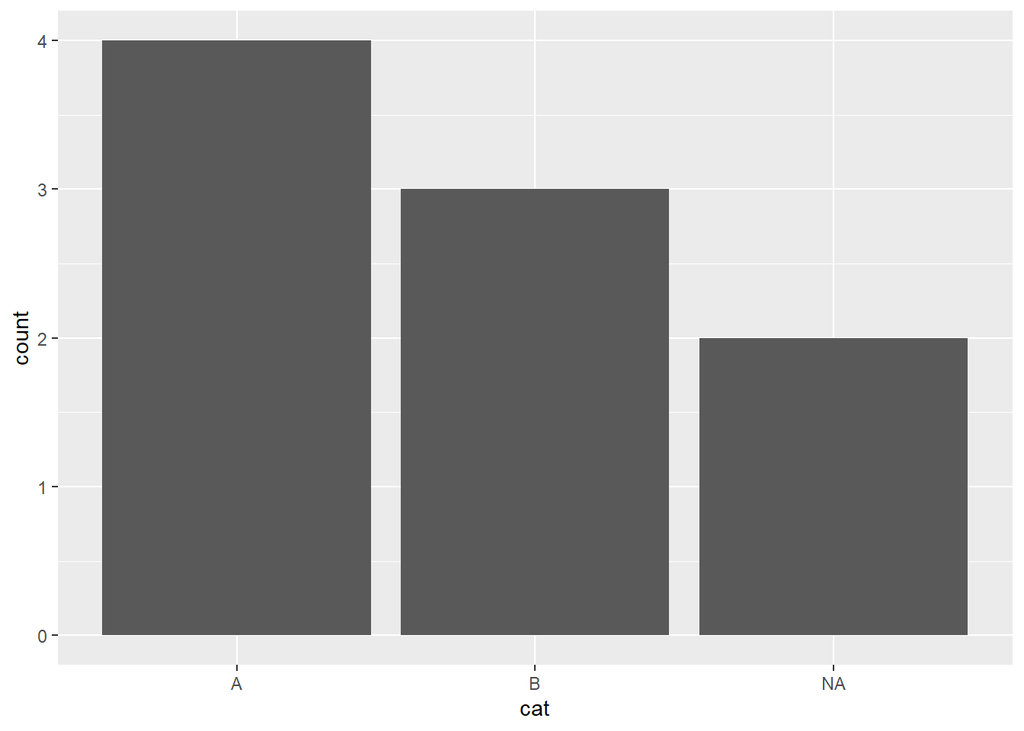

```r
# We make a dataframe with a categorical column, "cat", that contains four As, three Bs, and two NAs,
# and a continous column, "con", that contains four 3s, three 4s, and two NAs.
df = data.frame(
    cat = c('A', 'A', 'A', 'A', 'B', 'B', 'B', NA, NA),
    con = c(3, 3, 3, 3, 4, 4, 4, NA, NA)
)

# We plot a bar plot of x and a histogram of y:
ggplot(df) + geom_bar(aes(x=cat))
```

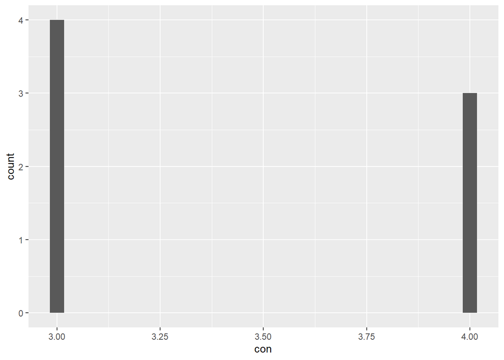

```r
ggplot(df) + geom_histogram(aes(x=con))
```

As we can see, geom_bar plots the NA category, but geom_histogram suppress the NA values. The reason for this is that for categorical data, NA can be interpreted as a category, and we may want to see on our chart how many values are in this category. On a histogram there is not a reasonable place to put NA values.